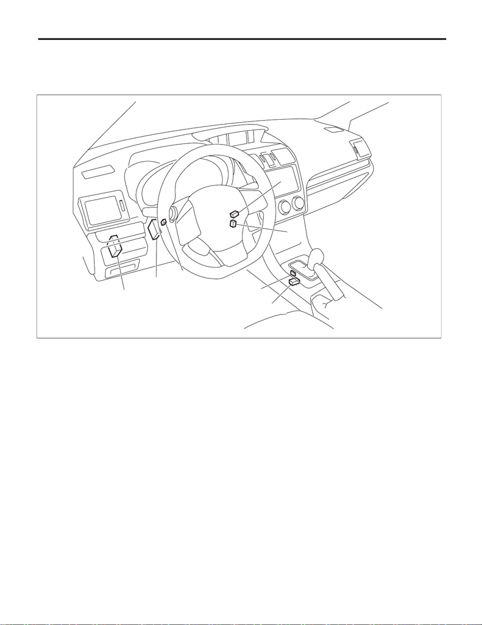

CS-7

AT Shift Lock Control System

CONTROL SYSTEMS

2. AT Shift Lock Control System

A: LOCATION

1. MODEL WITHOUT PUSH BUTTON IGNITION SWITCH

(1) TCM (“P” range) (4) Key cylinder (with built-in key

warning switch)

(6) “P” range switch

(2) Body integrated unit (5) Solenoid unit (7) Key lock solenoid

(3) Stop light and brake switch

CS-01773

(7)

(4)

(2)

(3)

(5)

(6)

(1)

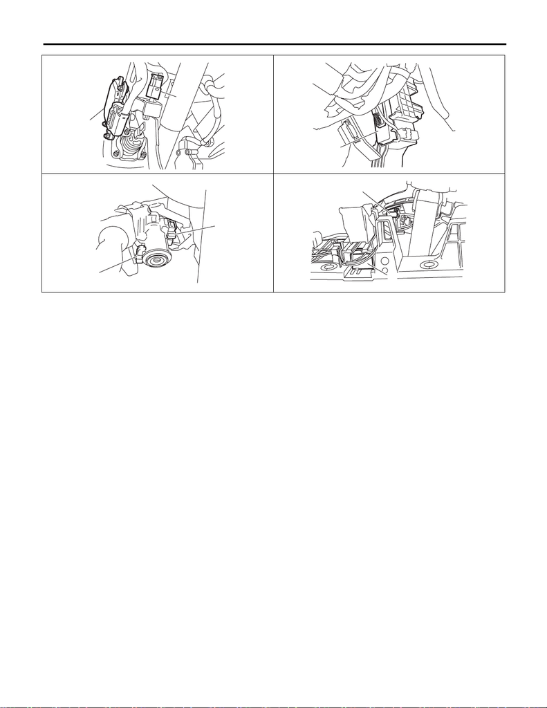

CS-8

AT Shift Lock Control System

CONTROL SYSTEMS

CS-01776

(1)

(3)

CS-01399

(2)

CS-01400

(4)

(7)

CS-01624

(5)

(6)

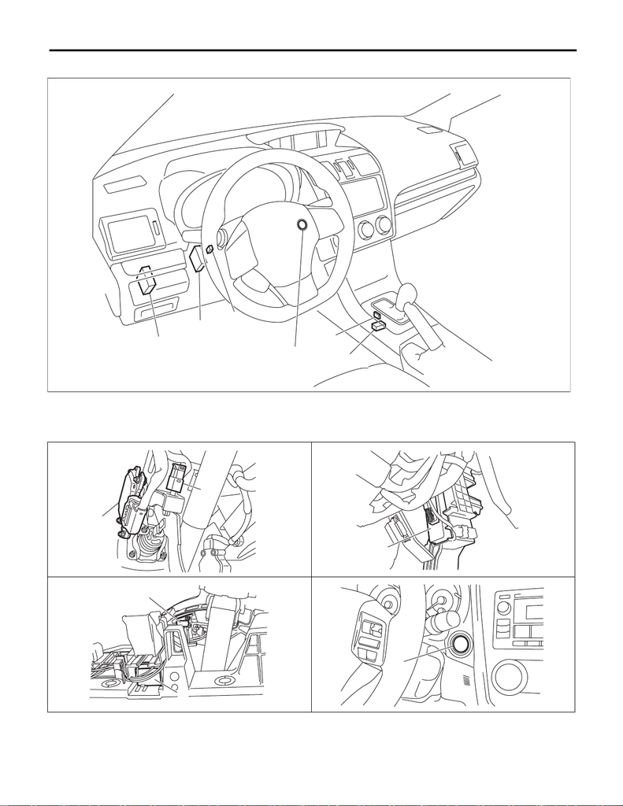

CS-9

AT Shift Lock Control System

CONTROL SYSTEMS

2. MODEL WITH PUSH BUTTON IGNITION SWITCH

(1) TCM (“P” range) (3) Stop light and brake switch (5) Solenoid unit

(2) Body integrated unit (4) Push button ignition switch (6) “P” range switch

CS-01772

(2)

(3)

(5)

(6)

(1)

(4)

CS-01776

(1)

(3)

CS-01399

(2)

CS-01624

(5)

(6)

CS-01661

(4)

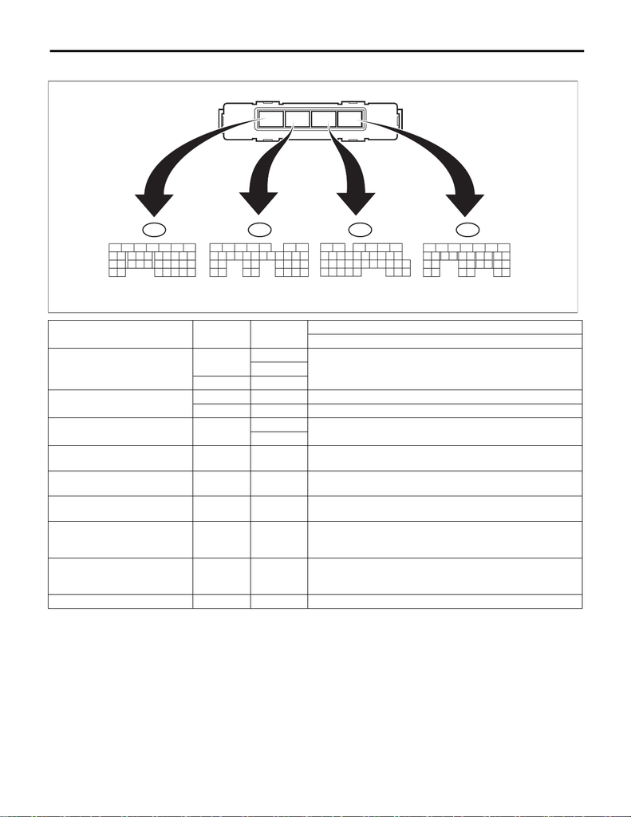

CS-10

AT Shift Lock Control System

CONTROL SYSTEMS

B: ELECTRICAL SPECIFICATION

Item

Connector

No.

Terminal

No.

Input/Output signal

Measured value and measuring conditions

Battery power supply

B281

6

i84 6

Ignition power supply

B280 32 10 — 15 V when ignition switch is at ACC.

B281 3 10 — 15 V when ignition switch is at ON or START.

TCM (“P” range) i84

27

Can not be measured because of digital communication

35

Stop light and brake switch B280 10

9 — 16 V when the stop light & brake switch is ON.

0 V when the stop light & brake switch is OFF.

“P” range switch B281 18

0 V when select lever is in “P” range.

9 — 16 V when select lever is in other positions than “P” range.

Solenoid unit signal B281 5

8.5 — 16 V when shift lock is released.

0 V when shift lock is operating.

Key warning switch signal

(Model without push button igni-

tion switch)

B280 4

9 — 16 V when key is inserted.

0 V when key is removed.

Key lock solenoid signal

(Model without push button igni-

tion switch)

B281 4

7.5 — 16 V when the key is inserted with the select lever shifted

in positions other than “P” range.

0 V at other conditions than above.

Ground B280 1 —

5672134

29

101112131415

25 24

16

30

98

17

18

19

20

28

212223

32 31

2627

333435

18

27 19202122

23

26

24

25

98

15

14 13 12 11 10

17

16

1234567

19

18

21

20

23 22242526

17

1

23

4

56

27

282930

3132333435

798

15 14 13 12 11 1016

19

18

2021

22

23

26

24

25

27

2829

3031

98

15

14 13 12 11 10

17

16

1234567

CS-01401

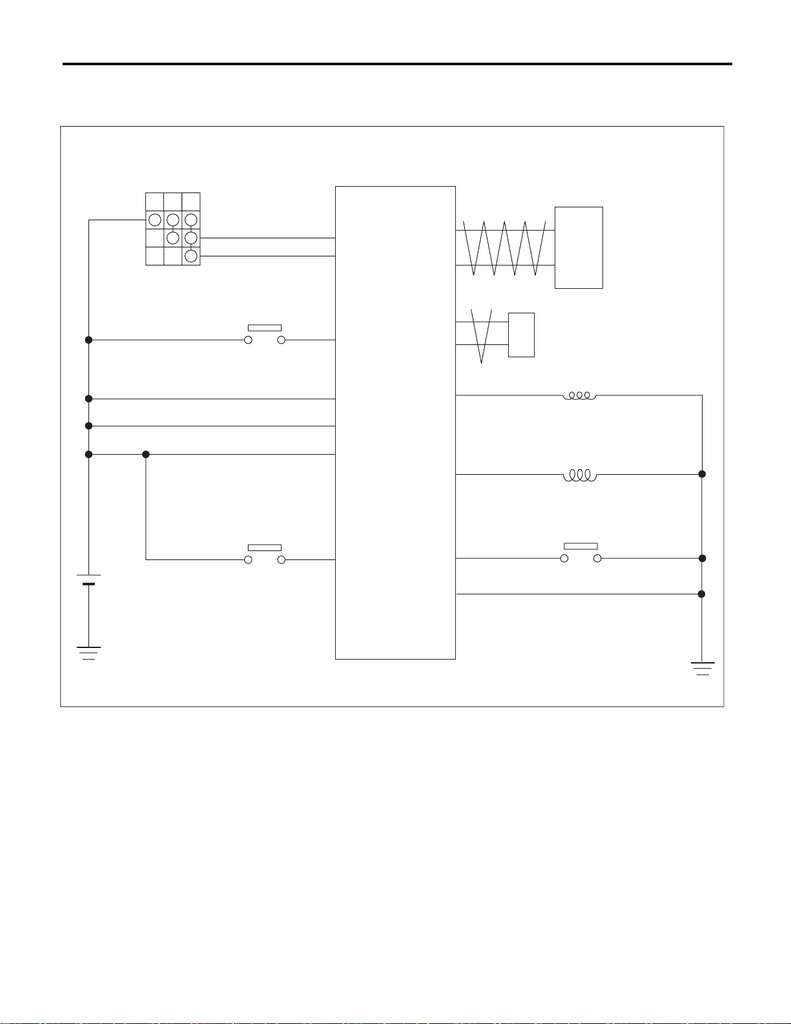

CS-11

AT Shift Lock Control System

CONTROL SYSTEMS

C: WIRING DIAGRAM

1. MODEL WITHOUT PUSH BUTTON IGNITION SWITCH

(1) Ignition switch (5) TCM (shift range information) (9) Battery

(2) Stop light and brake switch (6) Key lock solenoid (10) VDC CM (vehicle speed informa-

tion)

(3) Key warning switch (7) Shift lock solenoid

(4) Body integrated unit (8) “P” range switch

OFF ACC

ON

(1)

(2)

(3)

(4)

(9)

(6)

(7)

(8)

(5)

(10)

CS-01764

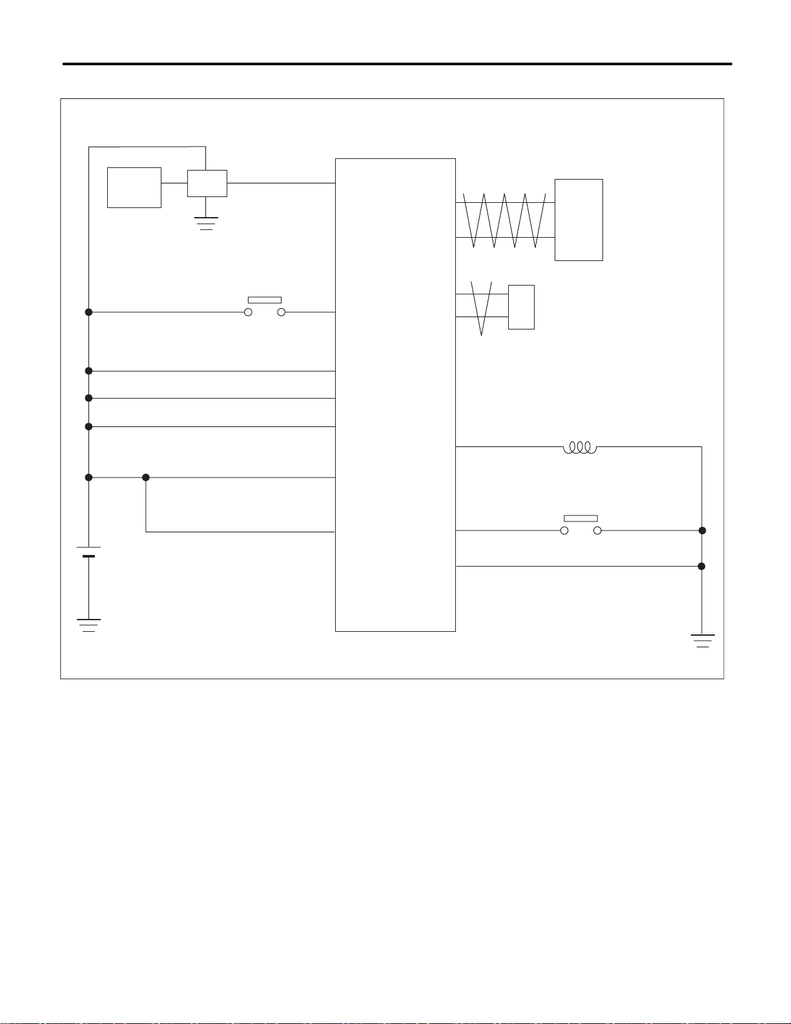

CS-12

AT Shift Lock Control System

CONTROL SYSTEMS

2. MODEL WITH PUSH BUTTON IGNITION SWITCH

(1) Keyless access CM (4) Battery (7) Shift lock solenoid

(2) IG relay 1 (push button start) (5) Body integrated unit (8) “P” range switch

(3) Stop light and brake switch (6) TCM (shift range information) (9) VDC CM (vehicle speed informa-

tion)

(1)

(3)

(2)

(4)

(7)

(8)

(6)

(9)

(5)

CS-01765

[figure not shown]

CS-13

AT Shift Lock Control System

CONTROL SYSTEMS

D: INSPECTION

1. SHIFT LOCK OPERATION

• Model without push button ignition switch

Step Check Yes No

1 CHECK COMMUNICATION OF SUBARU SE-

LECT MONITOR.

1) Turn the ignition switch to ON.

2) Using the Subaru Select Monitor, check

whether communication to all systems can be

executed normally.

Is the system name displayed? Go to step 2. Perform the

inspection follow-

ing the diagnostic

procedure in

BODY CONTROL

SYSTEM (DIAG-

NOSTICS) sec-

tion. <Ref. to

BC(diag)-2, Basic

Diagnostic Proce-

dure.>

2 CHECK SHIFT LOCK.

1) Turn the ignition switch to ON.

2) Shift the select lever to “P” range.

While brake pedal is not

depressed, is it possible to

move the select lever from the

“P” range to other ranges?

Perform the

inspection of

“SELECT LEVER

CANNOT BE

LOCKED OR

RELEASED”.

<Ref. to CS-18,

SELECT LEVER

CANNOT BE

LOCKED OR

RELEASED,

INSPECTION, AT

Shift Lock Control

System.>

Go to step 3.

3 CHECK SHIFT LOCK. While brake pedal is

depressed, is it possible to

move the select lever from the

“P” range to other ranges?

Go to step 4. Perform the

inspection of

“SELECT LEVER

CANNOT BE

LOCKED OR

RELEASED”.

<Ref. to CS-18,

SELECT LEVER

CANNOT BE

LOCKED OR

RELEASED,

INSPECTION, AT

Shift Lock Control

System.>

4 CHECK SHIFT LOCK.

Shift the select lever to “N” range.

Is it possible to move the select

lever from the “N” range to the

“P” range?

Go to step 5. Perform the

inspection of

“SELECT LEVER

CANNOT BE

LOCKED OR

RELEASED”.

<Ref. to CS-18,

SELECT LEVER

CANNOT BE

LOCKED OR

RELEASED,

INSPECTION, AT

Shift Lock Control

System.>

[figure not shown]

CS-14

AT Shift Lock Control System

CONTROL SYSTEMS

5 CHECK SHIFT LOCK.

1) Shift the select lever to “N” range.

2) Turn the ignition switch to ACC.

While brake pedal is

depressed, is it possible to

move the select lever from the

“N” range to the “P” range?

Go to step 6. Perform the

inspection of

“SELECT LEVER

CANNOT BE

LOCKED OR

RELEASED”.

<Ref. to CS-18,

SELECT LEVER

CANNOT BE

LOCKED OR

RELEASED,

INSPECTION, AT

Shift Lock Control

System.>

6 CHECK KEY INTERLOCK.

1) Turn the ignition switch to OFF.

2) Shift the select lever to other than “P” range.

Can the ignition key be

removed?

Perform the

inspection of “KEY

INTERLOCK CAN-

NOT BE LOCKED

OR RELEASED”.

<Ref. to CS-21,

KEY INTERLOCK

CANNOT BE

LOCKED OR

RELEASED,

INSPECTION, AT

Shift Lock Control

System.>

Go to step 7.

7 CHECK KEY INTERLOCK.

Shift the select lever to “P” range.

Can the ignition key be

removed?

AT shift lock sys-

tem is normal.

Perform the

inspection of “KEY

INTERLOCK CAN-

NOT BE LOCKED

OR RELEASED”.

<Ref. to CS-21,

KEY INTERLOCK

CANNOT BE

LOCKED OR

RELEASED,

INSPECTION, AT

Shift Lock Control

System.>

Step Check Yes No

1 CHECK COMMUNICATION OF SUBARU SE-

LECT MONITOR.

1) Turn the ignition switch to ON.

2) Using the Subaru Select Monitor, check

whether communication to all systems can be

executed normally.

Is the system name displayed? Go to step 2. Perform the

inspection follow-

ing the diagnostic

procedure in

BODY CONTROL

SYSTEM (DIAG-

NOSTICS) sec-

tion. <Ref. to

BC(diag)-2, Basic

Diagnostic Proce-

dure.>

Step Check Yes No

[figure not shown]

CS-15

AT Shift Lock Control System

CONTROL SYSTEMS

2 CHECK SHIFT LOCK.

1) Turn the ignition switch to ON.

2) Shift the select lever to “P” range.

While brake pedal is not

depressed, is it possible to

move the select lever from the

“P” range to other ranges?

Perform the

inspection of

“SELECT LEVER

CANNOT BE

LOCKED OR

RELEASED”.

<Ref. to CS-18,

SELECT LEVER

CANNOT BE

LOCKED OR

RELEASED,

INSPECTION, AT

Shift Lock Control

System.>

Go to step 3.

3 CHECK SHIFT LOCK. While brake pedal is

depressed, is it possible to

move the select lever from the

“P” range to other ranges?

Go to step 4. Perform the

inspection of

“SELECT LEVER

CANNOT BE

LOCKED OR

RELEASED”.

<Ref. to CS-18,

SELECT LEVER

CANNOT BE

LOCKED OR

RELEASED,

INSPECTION, AT

Shift Lock Control

System.>

4 CHECK SHIFT LOCK.

Shift the select lever to “N” range.

Is it possible to move the select

lever from the “N” range to the

“P” range?

Go to step 5. Perform the

inspection of

“SELECT LEVER

CANNOT BE

LOCKED OR

RELEASED”.

<Ref. to CS-18,

SELECT LEVER

CANNOT BE

LOCKED OR

RELEASED,

INSPECTION, AT

Shift Lock Control

System.>

5 CHECK SHIFT LOCK.

1) Shift the select lever to “N” range.

2) Turn the ignition switch to ACC.

While brake pedal is

depressed, is it possible to

move the select lever from the

“N” range to the “P” range?

AT shift lock sys-

tem is normal.

Perform the

inspection of

“SELECT LEVER

CANNOT BE

LOCKED OR

RELEASED”.

<Ref. to CS-18,

SELECT LEVER

CANNOT BE

LOCKED OR

RELEASED,

INSPECTION, AT

Shift Lock Control

System.>

Step Check Yes No

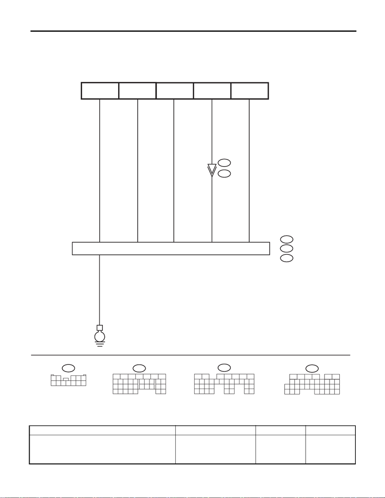

CS-16

AT Shift Lock Control System

CONTROL SYSTEMS

2. BODY INTEGRATED UNIT POWER SUPPLY AND GROUND CIRCUIT

NOTE:

For the DC power supply circuit, refer to “WIRING DIAGRAMS”. <Ref. to WI-28, Power Supply Circuit.>

Step Check Yes No

1 CHECK DTC OF BODY INTEGRATED UNIT.

Check DTC of body integrated unit.

<Ref. to BC(diag)-9, Read Diagnostic Trouble

Code (DTC).>

Is the DTC of power line dis-

played on body integrated unit?

Repair or replace it

according to the

DTC.

Go to step 2.

CS-01823

121110

9876

54321

i229

3

i229

B551

E

B3

B7

C6

i84

19

18

21

20

2322 24 25 26

17

1

23

4

56

27

28 29 30

31 32 33 34 35

798

151413121110 16

C:

B:

B281

5672134

29

10 11 12 13 14 15

2524

16

30

98

17 18 19

20

28

21 22 23

3231

26 27

33 34 35

A:

18

2719 20 21 22

23

26

24

25

98

15

1413121110

17

16

1234567

B280

A32

A1

C:

i84

B:

B281

A:

B280

B6

BODY INTEGRATED UNIT

TO POWER SUPPLY CIRCUIT

FB-29

F/B FUSE NO. 31

(ACC)

FB-18

F/B FUSE NO. 7

(B)

MB-29

M/B FUSE NO. 8

(B)

FB-38

F/B FUSE NO. 12

(IG)

MB-28

M/B FUSE NO. 14

(B)

[figure not shown]

CS-17

AT Shift Lock Control System

CONTROL SYSTEMS

2 CHECK HARNESS BETWEEN BODY INTE-

GRATED UNIT AND BATTERY.

1) Turn the ignition switch to ON.

2) Measure the voltage between body inte-

grated unit and chassis ground.

Connector & terminal

(B281) No. 3 (+) — Chassis ground (–):

(B280) No. 32 (+) — Chassis ground (–):

(B281) No. 6 (+) — Chassis ground (–):

(B281) No. 7 (+) — Chassis ground (–):

(i84) No. 6 (+) — Chassis ground (–):

Is the voltage 9 — 16 V? Go to step 3. Check harness for

open circuit

between the body

integrated unit and

the battery or a

blown fuse.

3 CHECK HARNESS BETWEEN BODY INTE-

GRATED UNIT AND CHASSIS GROUND.

1) Turn the ignition switch to OFF.

2) Measure the harness resistance between

the body integrated unit and chassis ground.

Connector & terminal

(B280) No. 1 — Chassis ground:

Is the resistance less than 1 Ω? Go to step 4. Repair the open

circuit of harness

between the body

integrated unit and

chassis ground.

4 CHECK FOR POOR CONTACT. Is there poor contact of connec-

tor?

Repair the poor

contact.

Check body inte-

grated unit.

Step Check Yes No

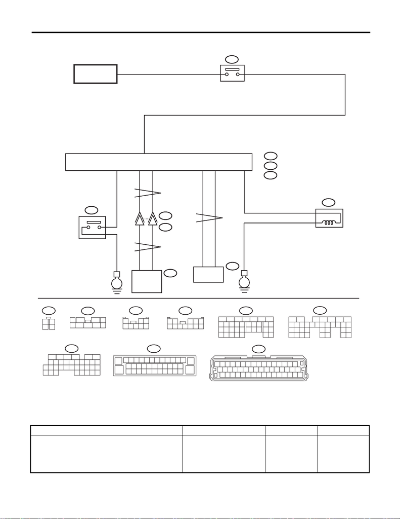

CS-18

AT Shift Lock Control System

CONTROL SYSTEMS

3. SELECT LEVER CANNOT BE LOCKED OR RELEASED

Step Check Yes No

1 CHECK BODY INTEGRATED UNIT POWER

SUPPLY AND GROUND CIRCUIT.

<Ref. to CS-16, BODY INTEGRATED UNIT

POWER SUPPLY AND GROUND CIRCUIT,

INSPECTION, AT Shift Lock Control System.>

Is there any fault? Follow the proce-

dures to perform

inspection and

repair.

Go to step 2.

B65

43

21

B54

123456789

10 11 12 13 14 15 16

17 18 19 20 21 22 23 24 25 26 27 28 29 30 31 32

33 34 35 36 37 38 39 40 41 42 43 44 45 46 47 48

121110

9876

54321

i229

7

B551

i229

6

i84

19

18

21

20

2322 24 25 26

17

1

23

4

56

27

28 29 30

31 32 33 34 35

798

151413121110 16

C:

10 11 12 13

14

23456789

15

26

16 17 18 19 20 21 22 23 24 25

27 28 29 30 31 32 33 34 35 36 37

1

38

B310

F:

B159

596

12 43

78

B116

321

87654

B:

B281

5672134

29

10 11

12 13 14 15

2524

16

30

98

17 18 19

20

28

21 22 23

3231

26 27

33 34 35

A:

18

2719 20 21 22

23

26

24

25

98

15

1413121110

17

16

1234567

B280

2

1

CS-01824

2

1

B116

B18

E

B310

35

36

B54

43

44

B28

B20

C27

C35

B65

3

4

B116

B5

A10

A: B280

C: i84

B: B281

E

TCM

VDC CM

BODY INTEGRATED UNIT

SHIFT LOCK

SOLENOID

P RANGE SWITCH

STOP LIGHT &

BRAKE SWITCH

FB-3

F/B FUSE NO. 8

(B)

TO POWER SUPPLY CIRCUIT

[figure not shown]

CS-19

AT Shift Lock Control System

CONTROL SYSTEMS

2 CHECK CURRENT DATA.

1) Connect the Subaru Select Monitor.

2) Shift the select lever to “P” range.

3) Turn the ignition switch to ON.

4) Select the current data display and display

«P SW». <Ref. to BC(diag)-15, Read Current

Data.>

Is the display “ON” in the P

range and “OFF” in ranges

other than P?

Go to step 3. Go to step 8.

3 CHECK CURRENT DATA.

Select the current data display and display

«Stop Light Switch». <Ref. to BC(diag)-15,

Read Current Data.>

Is “ON” displayed when the

brake pedal is depressed and

“OFF” displayed when the

brake pedal is released?

Go to step 4. Go to step 11.

4 CHECK BODY INTEGRATED UNIT DTC.

Check the DTC of the body integrated unit when

the brake pedal is pressed and when it is

released.

(Hold each condition for 5 seconds or more.)

Is there a DTC of a current mal-

function?

Follow the DTC to

perform inspection

and repair.

Go to step 5.

5 CHECK CURRENT DATA.

Select the current data display and display

«Shift Lock Solenoid». <Ref. to BC(diag)-15,

Read Current Data.>

Is “ON” displayed when the

brake pedal is depressed and

“OFF” displayed when the

brake pedal is released?

Go to step 6. Replace the body

integrated unit.

6 CHECK CURRENT DATA.

Select the current data display and display

«Shift Position». <Ref. to BC(diag)-15, Read

Current Data.>

Is the display “P” in the P range

and other than “P” in ranges

other than P?

Go to step 7. Check the follow-

ing items.

• Inhibitor switch

• Harness

between inhibitor

switch and TCM

• TCM input signal

• TCM CAN com-

munication

• Body integrated

unit CAN receive

7 CHECK CURRENT DATA.

1) Select the current data display and display

«Front Wheel Speed». <Ref. to BC(diag)-15,

Read Current Data.>

2) Start the engine.

3) Raise vehicle speed gradually up to approx-

imately 20 km/h (12 MPH).

Is a figure equivalent to the

speedometer being indicated?

Go to step 12. Check the follow-

ing items.

• Wheel speed

sensor

•CAN communi-

cation by VDC unit

• Body integrated

unit CAN receive

Replace the wheel

speed sensor,

VDC unit or body

integrated unit, or

both.

8 CHECK HARNESS BETWEEN BODY INTE-

GRATED UNIT AND “P” RANGE SWITCH.

1) Disconnect the connector from body inte-

grated unit.

2) Disconnect the connector of “P” range

switch.

3) Check for open circuit of harness, short cir-

cuit to battery or short circuit to ground between

the body integrated unit and “P” range switch.

Connector & terminal

(B281) No. 18 — (B116) No. 1:

Is there any fault in the har-

ness?

Repair or replace

the harness

between the body

integrated unit and

the “P” range

switch.

Go to step 9.

Step Check Yes No

[figure not shown]

CS-20

AT Shift Lock Control System

CONTROL SYSTEMS

9 CHECK HARNESS BETWEEN “P” RANGE

SWITCH AND CHASSIS GROUND.

Measure the resistance of harness between “P”

range switch and chassis ground.

Connector & terminal

(B116) No. 2 — Chassis ground:

Is it less than 10 Ω? Go to step 10. Repair the harness

between the “P”

range switch and

chassis ground.

10 CHECK “P” RANGE SWITCH.

Measure the resistance between “P” range

switch connector terminals.

Terminals

No. 2 — No. 1:

Is it less than 10 Ω in the “P”

range, and 1 MΩ or more in

ranges other than “P”?

Replace the body

integrated unit.

Replace the “P”

range switch.

11 CHECK STOP LIGHT SWITCH INPUT SIG-

NAL.

1) Disconnect the connector from body inte-

grated unit.

2) Measure the voltage between the body inte-

grated unit connector terminal and chassis

ground.

Connector & terminal

(B280) No. 10 (+) — Chassis ground (–):

Is the voltage 9 V to 16 V when

the brake pedal is depressed,

and approx. 0 V when not

depressed?

Replace the body

integrated unit.

Check the stop

light system.

12 CHECK SOLENOID UNIT OPERATION.

Connect the battery to the solenoid unit connec-

tor terminal, and operate the solenoid unit.

Terminals

No. 3 (+) — No. 4 (–):

Does the solenoid unit operate

normally?

Check the lock

mechanism of the

select lever body.

Replace the sole-

noid unit.

Step Check Yes No

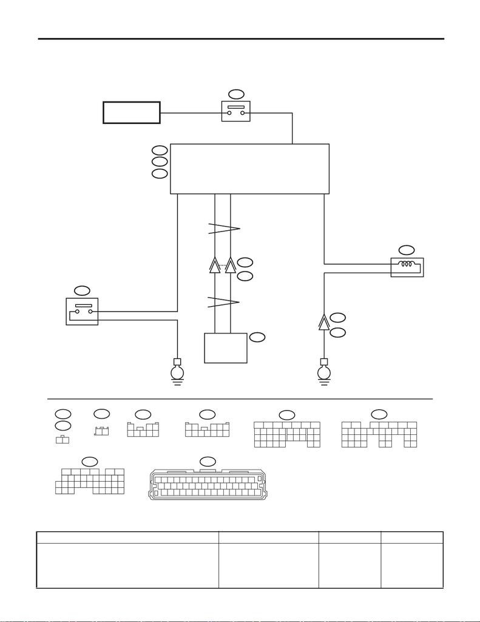

CS-21

AT Shift Lock Control System

CONTROL SYSTEMS

4. KEY INTERLOCK CANNOT BE LOCKED OR RELEASED

NOTE:

Check of this item only applies to models without a push button ignition switch.

Step Check Yes No

1 CHECK BODY INTEGRATED UNIT POWER

SUPPLY AND GROUND CIRCUIT.

<Ref. to CS-16, BODY INTEGRATED UNIT

POWER SUPPLY AND GROUND CIRCUIT,

INSPECTION, AT Shift Lock Control System.>

Is there any fault? Follow the proce-

dures to inspect

and repair.

Go to step 2.

B54

123456789

10 11 12 13 14 15 16

17 18 19 20 21 22 23 24 25 26 27 28 29 30 31 32

33 34 35 36 37 38 39 40 41 42 43 44 45 46 47 48

121110

9876

54321

i229

7

B551

i229

A:

18

2719 20 21 22

23

26

24

25

28 29 3332 3430 31

98

15

1413121110

17

16

1234567

B280

6

1

B54

43

44

21

B123

353433

2726

31 32

232221

28

20

191817

89

30

16

24 25

151413121110

29

4312 765

B281

B:

C:

1610 11 12 13 14 15

897

3534333231

302928

27

65

4

32

1

17

26252422 23

20

21

18

19

i84

B557

B116

321

87654

12

B555

CS-01825

2

1

B124

B123

B557

B555

2

1

B116

1

2

B18 C27 C35

B4

A4

A: B280

B: B281

C: i84

EE

TCM

KEY WARNING SWITCH

BODY INTEGRATED UNIT

P RANGE SWITCH

KEY LOCK

SOLENOID

MB-28

M/B FUSE NO. 14

(B)

TO POWER SUPPLY CIRCUIT

[figure not shown]

CS-22

AT Shift Lock Control System

CONTROL SYSTEMS

2 CHECK CURRENT DATA.

1) Connect the Subaru Select Monitor.

2) Shift the select lever to “P” range.

3) Turn the ignition switch to ON.

4) Select the current data display and display

«P SW». <Ref. to BC(diag)-15, Read Current

Data.>

Is the display “ON” in the P

range and “OFF” in ranges

other than P?

Go to step 3. Go to step 6.

3 CHECK CURRENT DATA.

1) Select the current data display and display

the «key-lock warning SW». <Ref. to BC(diag)-

15, Read Current Data.>

2) Turn the ignition switch to OFF.

Does the display change from

“ON” ←→ “OFF” when the key

is inserted and removed?

Go to step 4. Go to step 9.

4 CHECK CURRENT DATA.

1) Turn the ignition switch to ON.

2) Select the current data display and display

«Key locking output». <Ref. to BC(diag)-15,

Read Current Data.>

Is the display “OFF” in the P

range and “ON” in ranges other

than P?

Go to step 10. Go to step 5.

5 CHECK DTC OF BODY INTEGRATED UNIT.

1) Set the select lever to other than “P” range.

2) Check DTC of body integrated unit.

Is B1105 (key interlock circuit

abnormal) a current malfunc-

tion?

Follow the DTC to

perform inspection

and repair.

Go to step 10.

6 CHECK HARNESS BETWEEN BODY INTE-

GRATED UNIT AND “P” RANGE SWITCH.

1) Disconnect the connector from body inte-

grated unit.

2) Disconnect the connector of “P” range

switch.

3) Check for open circuit of harness, short cir-

cuit to battery or short circuit to ground between

the body integrated unit and “P” range switch.

Connector & terminal

(B281) No. 18 — (B116) No. 1:

Is there any fault in the har-

ness?

Repair or replace

the harness

between the body

integrated unit and

the “P” range

switch.

Go to step 7.

7 CHECK HARNESS BETWEEN “P” RANGE

SWITCH AND CHASSIS GROUND.

Measure the resistance of harness between “P”

range switch and chassis ground.

Connector & terminal

(B116) No. 2 — Chassis ground:

Is it less than 10 Ω? Go to step 8. Repair the harness

between the “P”

range switch and

chassis ground.

8 CHECK “P” RANGE SWITCH.

Measure the resistance between “P” range

switch connector terminals.

Terminals

No. 2 — No. 1:

Is it less than 10 Ω in the “P”

range, and 1 MΩ or more in

ranges other than “P”?

Replace the body

integrated unit.

Replace the “P”

range switch.

9 CHECK HARNESS BETWEEN BATTERY

AND KEY WARNING SWITCH AND BODY IN-

TEGRATED UNIT.

1) Disconnect the connector from body inte-

grated unit.

2) Measure the voltage between body inte-

grated unit and chassis ground.

Connector & terminal

(B280) No. 4 (+) — Chassis ground (–):

Is the display 9 V or more when

the key is inserted, and less

than 1.5 V with the key

removed?

Replace the body

integrated unit.

Check the follow-

ing items.

•Key warning

switch

• Harness/fuse

• Ignition circuit

Step Check Yes No

[figure not shown]

CS-23

AT Shift Lock Control System

CONTROL SYSTEMS

10 CHECK HARNESS BETWEEN BODY INTE-

GRATED UNIT AND KEY LOCK SOLENOID.

1) Disconnect the connector from body inte-

grated unit.

2) Disconnect the connector of key lock sole-

noid.

3) Check for open circuit of harness, short cir-

cuit to battery or short circuit to ground between

the body integrated unit and key lock solenoid.

Connector & terminal

(B281) No. 4 — (B557) No. 1:

Is there any fault in the har-

ness?

Repair or replace

the harness

between the body

integrated unit and

the key lock sole-

noid.

Go to step 11.

11 CHECK HARNESS BETWEEN KEY LOCK

SOLENOID AND CHASSIS GROUND.

Measure the resistance of harness between

key lock solenoid and chassis ground.

Connector & terminal

(B557) No. 2 — Chassis ground:

Is it less than 10 Ω? Go to step 12. Repair or replace

the harness

between the key

lock solenoid and

chassis ground.

12 CHECK KEY LOCK SOLENOID OPERATION.

Connect the battery to the key lock solenoid

connector terminal, and operate the solenoid.

Terminals

Does the key lock solenoid

operate normally?

Go to step 13. Replace the key

lock solenoid.

13 CHECK OUTPUT OF BODY INTEGRATED

UNIT.

1) Connect all connectors.

2) Insert the key.

3) Measure the voltage between body inte-

grated unit and chassis ground.

Connector & terminal

(B281) No. 4 — Chassis ground:

Is it 7.5 V to 16 V in ranges

other than “P”, and 0 V in the

“P” range?

Check the lock

mechanism of the

steering lock body.

Replace the body

integrated unit.

Step Check Yes No